# R Programming

This notebook contains notes taken from the Coursera course [R Programming](https://www.coursera.org/learn/r-programming) created by Johns Hopkins University.

## Week 1

### Reading and writing data into R

- `read.table, write.table` for reading/writing tabular data
- `readLines, writeLines` for reading/writing lines of a text file
- `source, dump` or `dget, dput` for reading/writing R code files

#### Tabular formats

`read.table` arguments:

- `file`, for filename/connection
- `header`, logical, indicates if there is a header line
- `sep`, string, indicates the column separator
- `colClasses`, vector, indicates class of each column (if blank, R will attempt to calculate)
- `nrows`, number of rows (if blank, R will calculate)
- `comment.char`, string, indicates comment character (default: `,` for `read.csv`)
- `skip`, number of lines to skip from the beginning (default: `#`)
- `stringsAsFactors` logical, should character variables be encoded as factors?

When reading large datasets:

- read [help page](https://www.rdocumentation.org/packages/utils/versions/3.6.2/topics/read.table) for `read.table`
- know how much memory is available, what other applications or users are using resources, what the OS is (32-bit or 64-bit?)
- roughly calculate amount of memory required to store the dataset:
- $\text{nrows} \times \text{ncolumns} \times 8 \text{ bytes/numeric}$
- set `comment.char = ""` if there are no comments
- set `nrows` so R can assign appropriate amount of memory (use `wc` in bash)
- specify `colClasses` so R doesn’t have to work each column class out. To work out classes of each column you can just check the first ~100 rows and loop over each column using `sapply`:

```r
initial <- read.table("datatable.txt", nrows = 100)
classes <- sapply(initial, class)
tabAll <- read.table("datatable.txt", colClasses = classes)
```

#### Textual formats

- `dump` or `dput` can preserve the *metadata* associated with specific columns or rows
- `dput` will *deparse* R objects, can pull metadata for us
- `dump` can be used on multiple R objects
- tend to work better with version control programs (*e.g.* git)
- can be safer for long-term storage as harder to repair corruption
- not very space-efficient

#### Interfacing with the outside world

- `file`, opens a connection to a file
- `gzfile`, opens up to a file compressed with gzip
- `url`, opens a connection to a webpage

Uses of connections:

- reading or writing specific lines of a text file or website:

```r
con1 <-gzfile("words.gz")
x <- readLines(con1, 10)

con2 <-url("http://www.sample.com")
y <- readLines(con2, 10)
```

### Subsetting data

#### Operators:

- `[]` always returns an object of the *same class* as the original, can be used to select *multiple elements*
- `[[]]` extracts elements of a list or data frame, can only extract a *single* *element*, class of returned object will not necessarily be the same
- `$` extracts *named* elements of a list or data frame

#### Subsetting vectors:

```r
x <- c("a", "b", "c", "c", "d", "a")
x[1:4] # values in [] are a numeric index
```

```
[1] "a" "b" "c" "c"
```

```r
x[x > "a"] # value in [] is a logical index
```

```
[1] "b" "c" "c" "d"
```

#### Subsetting lists:

```r
x <-list(foo = 1:4, bar = 0.6)
x[1] # will generate a list
```

```
$foo
[1] 1 2 3 4
```

```r
x[[1]] # will generate a sequence (not a list)
```

```
[1] 1 2 3 4
```

```r
x$bar # will get the object "bar"
```

```
[1] 0.6
```

**NB:** `[[]]` operator can also be used with *computed indices* which are put into variables, whereas `$` can only be used with *literal* names.

#### Subsetting matrices:

```r
x <- matrix(1:6, 2, 3) # creates a matrix
x
```

```
     [,1] [,2] [,3]
[1,]    1    3    5
[2,]    2    4    6
```

```r
x[1, 2] # subsets object in first row, second column
```

```
[1] 3
```

```r
x[, 2] # subsets entire second column
```

```
[1] 3 4
```

**NB:** By default, when a single element, column or row is retrieved with `[]`, it will return a *vector* of length 1. To return a 1×1 *matrix*, set `drop = FALSE`.

#### Subsetting with names:

Partial matching of names is possible using the `[[]]` and `$` operators.

```r
x <- list(aardvark = 1:5)
x$a
```

```
[1] 1 2 3 4 5
```

```r
x[["a"]] # expects an exact match
```

```r
x[["a", exact = FALSE]] # will extract a partial match
```

```
[1] 1 2 3 4 5
```

#### Removing missing data:

```r
x <- c(1, NA, NA, 4, NA, 5)
bad <- is.na(x) # vector of NA values in x
x[!bad] # returns vector of values in x that are *not* NA
```

```
[1] 1 4 5
```

```r
y <- c("a", "b", NA, "d", NA, "f")
good <- complete.cases(x,y) # vector where *both* elements are *not* NA
y[good]
```

```
[1] "a" "d" "f"
```

```r
airquality[1:6, ] # this table has missing values
```

|  | Ozone | Solar.R | Wind | Temp | Month | Day |
| --- | --- | --- | --- | --- | --- | --- |
| 1 | 41 | 190 | 7.4 | 67 | 5 | 1 |
| 2 | 36 | 118 | 8.0 | 72 | 5 | 2 |
| 3 | 12 | 149 | 12.6 | 74 | 5 | 3 |
| 4 | 18 | 313 | 11.5 | 62 | 5 | 4 |
| 5 | NA | NA | 14.3 | 56 | 5 | 5 |
| 6 | 28 | NA | 14.9 | 66 | 5 | 6 |

```r
good <- complete.cases(airquality) # vector of rows with no missing data
airquality[good, ][1:6, ] # now only includes rows without missing values
```

|  | Ozone | Solar.R | Wind | Temp | Month | Day |
| --- | --- | --- | --- | --- | --- | --- |
| 1 | 41 | 190 | 7.4 | 67 | 5 | 1 |
| 2 | 36 | 118 | 8.0 | 72 | 5 | 2 |
| 3 | 12 | 149 | 12.6 | 74 | 5 | 3 |
| 4 | 18 | 313 | 11.5 | 62 | 5 | 4 |
| 7 | 23 | 299 | 8.6 | 65 | 5 | 7 |
| 8 | 19 | 99 | 13.8 | 59 | 5 | 8 |

### Vectorised operations

R’s ability to perform vectorised operations reduces your need to write `for` or `while` loops for simple calculations.

```r
x <- 1:4
y <- 6:9
x + y # adds nth value from x to equivalent value of y in parallel
```

```
[1]  7  9 11 13
```

```r
x > 2 # compares all values in x to 2
```

```
[1] FALSE FALSE  TRUE  TRUE
```

```r
x <- matrix(1:4, 2, 2)
y <- matrix(rep(10,4), 2, 2)
x * y # this will perform an *element-wise multiplication*
```

```
     [,1] [,2]
[1,]   10   30
[2,]   20   40
```

```r
x %*% y # this will perform a *true matrix multiplication*
```

```
     [,1] [,2]
[1,]   40   40
[2,]   60   60
```

## Week 2

### Control Structures

- `if`, `else`: test a condition
- `for`: execute a loop a fixed number of times
- `while`: execute a loop while a condition is true (*can be infinite if* *condition is never true*)
- `repeat`: execute an infinite loop
- `break`: break out of a loop entirely
- `next`: skip an iteration in a loop
- `return`: exit a function and return a value

For example:

```r
if (x > 3) {
  y <- 10
} else {
  y <- 0
}
```

```
the condition has length > 1 and only the first element will be used
```

```r
# or we can assign the entire construct to y

y <- if(x > 3) {
  10
} else {
  0
}
```

```
the condition has length > 1 and only the first element will be used
```

### Writing functions

- created using `function()`
- treated as objects, therefore can be passed as arguments to other functions and can be *nested* inside one another
- return value of a function is the last expression to be evaluated

#### Arguments:

- *named arguments* can have *default values*
- *formal arguments* are included in the function’s definition
- `formals` function will return a list of all formal arguments in a function
- not every function uses all formal arguments, some can be missing or will have default values
- arguments can be matched *positionally* (by position in the function definition) or *by name* (with `=`)
- **NB**: when an argument is matched *by name* it is “taken out” of the argument list, the remaining arguments will be matched *positionally*
- **NB**: function arguments can also be *partially* matched with the following logic:
1. look for exact match for named argument
2. look for partial match
3. perform positional match
- the ellipsis (…) argument can be used to indicate a *variable number of arguments* that are passed on to other functions
- **NB**: any functions after the ellipsis argument must be explicit and *cannot* be partically matched

#### Lazy evaluation:

R will only evaluate function arguments *as needed*, for example:

```r
f <- function(a, b) {
  print(a)
  print(b)
}
f(45)
```

```
[1] 45
```

```
Error in print(b) : argument "b" is missing, with no default
```

Note how the error only occured *after* the first argument was evaluated and the first value was printed out.

#### Examples of writing functions:

```r
add2 <- function(x, y){
  x + y
}

# once we've defined the function, we can call it like so:

add2(5, 6)
```

```
[1] 11
```

```r
above_n <- function(x, n = 10) {
  use <- x > n # work out which elements are > n (default to 10)
  x[use] # return those values
}

above_n(1:20, 12)
```

```
[1] 13 14 15 16 17 18 19 20
```

```r
above_n(1:20) # without n input, will default to n = 10
```

```
 [1] 11 12 13 14 15 16 17 18 19 20
```

```r
columnmean <- function(y, removeNA = TRUE) {
  nc <- ncol(y) # count the columns in df/matrix
  means <- numeric(nc) # initialise empty vector of same length to store means
  for(i in 1:nc) { # for each number from 1 to [number of columns]
    means[i] <- mean(y[, i], na.rm = removeNA) # add mean of the ith column
    # remove missing values if removeNA = TRUE.
  }
  means # return the vector of means
}

columnmean(airquality) # test on a dataset
```

```
[1]  42.129310 185.931507   9.957516  77.882353   6.993464  15.803922
```

**NB**: Generally it is best to save functions as R scripts and source them into R. Here they are included in the notebook for simplicity’s sake.

### Coding Standards for R

1. Always use plain text
2. Indent your code (*e.g.* 4 to 8 char)
3. Limit code width (*e.g.* to 80 columns)

This will make you limit sizes of functions, and will make your code more readable to yourself and to others and easier to debug if things go wrong.

### Dates and Times in R

Dates and times are represented in special classes:

- `Date` for dates, stored as number of *days* since 1970-01-01
- `POSIXct` and `POSIXlt` for times, stored as number of *seconds* since 1970-01-01
  - `POSIXct` stores information as a large integer, useful for storing times in data frames, etc.
  - `POSIXlt` stores information as a *list*, can include other useful info.
- a number of generic functions give us other info when applied to dates/times:
  - `weekdays` gives day of the week
  - `months` gives the month
  - `quarters` gives the annual quarter (Q1 - Q4)
- the `strptime` function can convert dates written in strings in different string formats to `Date`/`POSIXlt`format
- you can perform mathematical operations on dates/times *so long as they are* *in the same format*

Example of converting to date:

```r
x <- as.Date("1992-04-11")
x # looks like a character string
```

```
[1] "1992-04-11"
```

```r
class(x) # actually a Date class
```

```
[1] "Date"
```

```r
unclass(x) # raw data stored as a number of days
```

```
[1] 8136
```

Example of mathematical operations with dates:

```r
x <- as.Date("2012-03-01")
y <- as.Date("2012-02-28")

x - y # Find difference (in days) between two dates.
```

```
Time difference of 2 days
```

**NB**: R will take care of complicating facors such as leap years, time zones, etc. automatically.

## Week 3

### Loop functions

- `lapply`: Loop over a list, apply a function to each element
- `sapply`: Same as `lapply` but try to simplify the result
- `apply`: Apply a function over the margins of an array (*e.g.* summarise matricies, etc.)
- `tapply`: Apply a function over subsets of a vector
- `mapply`: Multivariate version of `lapply`
- `split`: Splits objects into sub-spieces, often used in conjunction with the above functions

#### lapply

`lapply` takes three arguments:

1. a list (`x`)
2. a function (`FUN`)
3. other arguments (`...`)

**NB:** If `x` is not a list, it will be coerced using `as.list`. Output will *always be a list*.

```r
lapply
```

```
function (X, FUN, ...)
{
    FUN <- match.fun(FUN)
    if (!is.vector(X) || is.object(X))
        X <- as.list(X)
    .Internal(lapply(X, FUN))
}
<bytecode: 0x00000181614b45c8>
<environment: namespace:base>
```

For example:

```r
x <- list(a = 1:5, b = rnorm(10))
lapply(x, mean)
```

```
$a
[1] 3

$b
[1] 0.399747
```

```r
x <- 1:4
lapply(x, runif, min = 0, max = 10)  # call runif on each element of x
```

```
[[1]]
[1] 3.893811

[[2]]
[1] 7.8841554 0.8336992

[[3]]
[1] 5.547344 3.898382 7.311332

[[4]]
[1] 5.438788 5.550614 3.914230 6.294180
```

```r
x <- list(a = matrix(1:4, 2, 2), b = matrix(1:6, 3, 2))
# suppose we want to extract the first column from each matrix?
# we can write an *anonymous function* which will only exist within this loop:
lapply(x, function(element) element[, 1])
```

```
$a
[1] 1 2

$b
[1] 1 2 3
```

### sapply

`sapply` tries to *simplify* `lapply` output, *e.g.*:

- If the result is a list where every element has length = 1, return a *vector*.
- If the result is a list where every element has equal length > 1, return a *matrix*.
- If the result can’t be simplified, just return a list.

### apply

`apply` is usually used to evaluate a (often anonymous) function over the margins of an array.

- Usually this means applying a function to the *rows or columns of a matrix*.
- Can also be used with general arrays, *e.g.* mean of an array of matricies.
- Not really faster than writing a loop, but works in one line, very useful on the command line.

```r
str(apply)
```

```
function (X, MARGIN, FUN, ...)
```

- `X` is an *array*.
- `MARGIN` is an integer vector indicating which *margins* should be “retained”.
- `FUN` is the function to be applied.
- `...` is for other arguments passed to `FUN`.

For example:

```r
x <- matrix(rnorm(200), 20, 10) # a matrix of 20 x 10
apply(x, 2, mean) # calculate the mean of each column of the matrix
```

```
 [1] -0.20292094 -0.35244184  0.35335613  0.03343769 -0.04169519  0.21593335  0.19778669 -0.28535305 -0.35817523 -0.09795148
```

```r
apply(x, 1, sum) # calculate the sum of each row of the matrix
```

```
 [1]  0.59983912  2.78134835  0.83130489  2.43428686 -0.06210892  2.28944807  1.47023871 -4.34780023 -0.50103612 -6.40979980
[11] -1.87938284  0.50163399 -0.31309002 -1.53919486 -1.48418489 -0.81667390 -0.76456121 -3.79294834 -4.26054556  4.50274919
```

**NB**: The *margin* here indicates the *dimension* of the matrix we want to ‘keep’. For sums and means of matricies there are actually some shortcuts:

- `rowSums = apply(x, 1, sum)`
- `rowMeans = apply(x, 1, mean)`
- `colSums = apply(x, 2, sum)`
- `colMeans = apply(x, 2, mean)`

Other examples:

```r
x <- matrix(rnorm(200), 20, 10)
apply(x, 1, quantile, probs = c(0.25, 0.75)) # get quantiles of each row
```

```
          [,1]        [,2]       [,3]       [,4]        [,5]       [,6]       [,7]        [,8]      [,9]      [,10]      [,11]
25% -0.6949905 -0.42059248 0.01674196 -0.5887117 -0.86362149 -0.4981837 -1.0133901 -0.77326712 -0.917481 -0.1540765 -0.3706486
75%  0.9251767  0.03127895 0.38382801  0.7000215  0.03258968  0.7179159  0.1325692  0.00429806  1.389655  0.7540952  0.7414770
         [,12]        [,13]     [,14]      [,15]      [,16]      [,17]       [,18]      [,19]      [,20]
25% -0.1258591 -0.466197322 -1.365178 -0.4011382 -0.5813137 -0.4608918 -0.79909636 -0.9884287 -1.0853853
75%  0.6328193  0.004061503  0.210939  0.3585018  0.3347432  0.5750612 -0.02125704  0.7307705  0.8761715
```

```r
a <- array(rnorm(2 * 2 * 10), c(2, 2, 10)) # 3-dimensional array
apply(a, c(1, 2), mean) # get the average of these 2x2 matricies, keep dim 1 & 2
```

```
            [,1]       [,2]
[1,] -0.08690055  0.0900408
[2,] -0.58692019 -0.2894571
```

```r
rowMeans(a, dims = 2) # can also use rowMeans
```

```
            [,1]       [,2]
[1,] -0.08690055  0.0900408
[2,] -0.58692019 -0.2894571
```

### mapply

`mapply` applies a function *in parallel* over a set of arguments, for example if we have *two* lists we want to apply a function over.

```r
str(mapply)
```

```
function (FUN, ..., MoreArgs = NULL, SIMPLIFY = TRUE, USE.NAMES = TRUE)
```

- `FUN` is the function to apply.
- `...` contains the list of arguments to apply over.
- `MoreArgs` is a list of other arguments of `FUN`
- `SIMPLIFY`indicates whether to simplify result like in `sapply`.

**NB**: The function you use must have at least the same number of arguments as items in the list of arguments you pass to it.

For example: Instead of typing `list(rep(1, 4), rep(2, 3), rep (3, 2), rep (4, 1)) we can do:

```r
mapply(rep, 1:4, 4:1)
```

```
[[1]]
[1] 1 1 1 1

[[2]]
[1] 2 2 2

[[3]]
[1] 3 3

[[4]]
[1] 4
```

### tapply

`tapply` applies functions over *subsets of a vector*.

```r
str(tapply)
```

```
function (X, INDEX, FUN = NULL, ..., default = NA, simplify = TRUE)
```

- `X` is a *vector*.
- `INDEX` is a factor/list of factors, indicating your *subset*.
- `FUN` is the function to be applied.
- `...` contains other arguments passed to `FUN`.
- `simplify` is same as in `sapply`.

For example:

```r
x <- c(rnorm(10), runif(10), rnorm(10, 1)) # our vector of three distributions
f <- gl(3, 10) # our factor, with three levels, each repeated 10 times
tapply(x, f, mean) # get the mean of each of the three groups in x
```

```
         1          2          3
0.08722757 0.46776023 1.16591588
```

### split

`split` takes a vector or other object and splits it into groups determined by a factor or list of factors. It will always return a *list*.

It is similar to `tapply` but without applying the summary statistics.

```r
str(split)
```

```
function (x, f, drop = FALSE, ...)
```

- `x` is an object.
- `f` is a factor/list of factors.
- `drop` indicates whether *empty* factor levels should be dropped.

For example:

```r
x <- c(rnorm(10), runif(10), rnorm(10, 1))
f <- gl(3, 10)
split(x, f)
```

```
$`1`
 [1] -1.5506366  1.1928761  0.3790850  1.1977380 -0.1622347  0.5128979 -2.5419084 -0.7538613  0.7821188 -0.6225115

$`2`
 [1] 0.65871979 0.65526987 0.01871826 0.10518723 0.44036827 0.80074718 0.09275838 0.38128400 0.25531860 0.61633705

$`3`
 [1] -0.2210580 -0.9153733  2.7798259 -0.8593761 -0.2604924  1.3789591  1.1613055  1.8956750  0.6381626 -0.1087550
```

Here we see `split` has split out vector of three distributions into a list with 3 parts. We can also split a *data frame*:

```r
library(datasets)
s <- split(airquality, airquality$Month) # split data frame by Month (-> factor)
sapply(s, function(x) colMeans(x[, c("Ozone", "Solar.R", "Wind")], na.rm=TRUE))
```

```
                5         6          7          8         9
Ozone    23.61538  29.44444  59.115385  59.961538  31.44828
Solar.R 181.29630 190.16667 216.483871 171.857143 167.43333
Wind     11.62258  10.26667   8.941935   8.793548  10.18000
```

We can also split on *multiple levels*:

```r
x <- rnorm(10) # vector
f1 <- gl(2, 5) # first factor, 2 levels, each repeated 5 times
f2 <- gl(5, 2) # second factor, 5 levels, each repeated 2 times
str(split(x, list(f1, f2), drop = TRUE)) # automatically gets the interactions
```

```
List of 6
 $ 1.1: num [1:2] 0.876 0.764
 $ 1.2: num [1:2] -0.497 0.318
 $ 1.3: num -0.279
 $ 2.3: num 0.87
 $ 2.4: num [1:2] -0.9649 0.0303
 $ 2.5: num [1:2] -0.451 1.305
```

### Debugging

When there is a problem, R can return certain notifications:

- `message`: generic notification, execution of function continues.
- `warning`: indication something is wrong, execution of function continues.
- `error`: indication of fatal problem, execution is stopped.
  - these are all a `condition`: indicates that something unexpected occurred.

Questions to ask yourself when debugging:

- What was the actual input?
- How was the function called?
- What were you expecting? Output, messages, other result?
- What did you get instead?
- How does what you got differ from what you expected?
- Were your expectations correct in the first place?
- Can you reproduce the problem exactly?

Base R has certain tools built in for debugging:

- `traceback`: prints out the *function call stack* after an error occurs.
- `debug`: flags a function for “debug” mode, allowing you to step through execution *one step at a time*.
- `browser`: suspends the execution of a function *wherever it is called* and puts it in “debug” mode.
- `trace`: lets you insert debugging code into a function without actually editing the function itself.
- `recover`: allows you to modify the error behaviour, so you can browse the function call stack, (*e.g.* not go straight back to console).

### str

`str` compactly displays the internal function of an R object. It is useful as a diagnostic function as an alternative to `summary`.

- Well suited to compactly display large, nested lists.
- Approximately one line per basic object.
- Answers question “What’s in this object?”

For example:

```r
str(lm) # looking into functions
```

```
function (formula, data, subset, weights, na.action,
    method = "qr", model = TRUE, x = FALSE, y = FALSE,
    qr = TRUE, singular.ok = TRUE, contrasts = NULL,
    offset, ...)
```

```r
x <- rnorm(100, 2, 4)
str(x) # looking into objects
```

```
 num [1:100] -0.383 4.559 0.502 4.576 6.701 ...
```

```r
f <- gl(40,10)
str(f) # looking into factors
```

```
 Factor w/ 40 levels "1","2","3","4",..: 1 1 1 1 1 1 1 1 1 1 ...
```

```r
str(airquality) # looking into a data frame
```

```
'data.frame':   153 obs. of  6 variables:
 $ Ozone  : int  41 36 12 18 NA 28 23 19 8 NA ...
 $ Solar.R: int  190 118 149 313 NA NA 299 99 19 194 ...
 $ Wind   : num  7.4 8 12.6 11.5 14.3 14.9 8.6 13.8 20.1 8.6 ...
 $ Temp   : int  67 72 74 62 56 66 65 59 61 69 ...
 $ Month  : int  5 5 5 5 5 5 5 5 5 5 ...
 $ Day    : int  1 2 3 4 5 6 7 8 9 10 ...
```

```r
s <- split(airquality, airquality$Month) # looking into a list
str(s)
```

```
List of 5
 $ 5:'data.frame':  31 obs. of  6 variables:
  ..$ Ozone  : int [1:31] 41 36 12 18 NA 28 23 19 8 NA ...
  ..$ Solar.R: int [1:31] 190 118 149 313 NA NA 299 99 19 194 ...
  ..$ Wind   : num [1:31] 7.4 8 12.6 11.5 14.3 14.9 8.6 13.8 20.1 8.6 ...
  ..$ Temp   : int [1:31] 67 72 74 62 56 66 65 59 61 69 ...
  ..$ Month  : int [1:31] 5 5 5 5 5 5 5 5 5 5 ...
  ..$ Day    : int [1:31] 1 2 3 4 5 6 7 8 9 10 ...
 $ 6:'data.frame':  30 obs. of  6 variables:
  ..$ Ozone  : int [1:30] NA NA NA NA NA NA 29 NA 71 39 ...
  ..$ Solar.R: int [1:30] 286 287 242 186 220 264 127 273 291 323 ...
  ..$ Wind   : num [1:30] 8.6 9.7 16.1 9.2 8.6 14.3 9.7 6.9 13.8 11.5 ...
  ..$ Temp   : int [1:30] 78 74 67 84 85 79 82 87 90 87 ...
  ..$ Month  : int [1:30] 6 6 6 6 6 6 6 6 6 6 ...
  ..$ Day    : int [1:30] 1 2 3 4 5 6 7 8 9 10 ...
 $ 7:'data.frame':  31 obs. of  6 variables:
  ..$ Ozone  : int [1:31] 135 49 32 NA 64 40 77 97 97 85 ...
  ..$ Solar.R: int [1:31] 269 248 236 101 175 314 276 267 272 175 ...
  ..$ Wind   : num [1:31] 4.1 9.2 9.2 10.9 4.6 10.9 5.1 6.3 5.7 7.4 ...
  ..$ Temp   : int [1:31] 84 85 81 84 83 83 88 92 92 89 ...
  ..$ Month  : int [1:31] 7 7 7 7 7 7 7 7 7 7 ...
  ..$ Day    : int [1:31] 1 2 3 4 5 6 7 8 9 10 ...
 $ 8:'data.frame':  31 obs. of  6 variables:
  ..$ Ozone  : int [1:31] 39 9 16 78 35 66 122 89 110 NA ...
  ..$ Solar.R: int [1:31] 83 24 77 NA NA NA 255 229 207 222 ...
  ..$ Wind   : num [1:31] 6.9 13.8 7.4 6.9 7.4 4.6 4 10.3 8 8.6 ...
  ..$ Temp   : int [1:31] 81 81 82 86 85 87 89 90 90 92 ...
  ..$ Month  : int [1:31] 8 8 8 8 8 8 8 8 8 8 ...
  ..$ Day    : int [1:31] 1 2 3 4 5 6 7 8 9 10 ...
 $ 9:'data.frame':  30 obs. of  6 variables:
  ..$ Ozone  : int [1:30] 96 78 73 91 47 32 20 23 21 24 ...
  ..$ Solar.R: int [1:30] 167 197 183 189 95 92 252 220 230 259 ...
  ..$ Wind   : num [1:30] 6.9 5.1 2.8 4.6 7.4 15.5 10.9 10.3 10.9 9.7 ...
  ..$ Temp   : int [1:30] 91 92 93 93 87 84 80 78 75 73 ...
  ..$ Month  : int [1:30] 9 9 9 9 9 9 9 9 9 9 ...
  ..$ Day    : int [1:30] 1 2 3 4 5 6 7 8 9 10 ...
```

### Simulation

Generally probability distribution functions have four functions associated with them, each prefixed with a:

- `d` for density
- `r` for random number
- `p` for cumulative distribution ("probability)
- `q` for quantile function

For example, the functions for Normal distributions are:

- `rnorm`: generate random Normal variates within given mean and standard deviation.
- `dnorm`: evaluate Normal probability density (w/ mean and SD) at a point.
- `pnorm`: evaluate cumulative distribution function for a Normal distribution.
- `qnorm`: evaluate quantiles from Normal distribution.

```r
dnorm(x, mean = 0, sd = 1, log = FALSE)
pnorm(q, mean = 0, sd = 1, lower.tail = TRUE, log.p = FALSE)
qnorm(p, mean = 0, sd = 1, lower.tail = TRUE, log.p = FALSE)
rnorm(n, mean = 0, sd = 1)
```

To generate random numbers:

```r
x <- rnorm(10, 20, 2) # get 10 random numbers with a mean of 20 and sd of 2
x
```

```
 [1] 20.01930 17.90682 22.17696 22.13393 23.80705 22.19911 21.29858 21.88352 23.90789
[10] 19.57203
```

```r
summary(x)
```

```
   Min. 1st Qu.  Median    Mean 3rd Qu.    Max.
  17.91   20.34   22.01   21.49   22.19   23.91
```

**NB**: Setting seeds when producing “random” numbers ensures reproducability. This is because computers aren’t capable of producing truly random numbers, but instead produce numbers which are *close enough* to random for our purposes based on an initial seed. We should always set a seed when generating random numbers for simluations so that our results can be reproduced by someone else, *e.g.*:

```r
set.seed(1)
rnorm(5)
```

```
[1] -0.6264538  0.1836433 -0.8356286  1.5952808  0.3295078
```

```r
rnorm(5) # without setting seed, we will get DIFFERENT "random" numbers
```

```
[1] -0.8204684  0.4874291  0.7383247  0.5757814 -0.3053884
```

```r
set.seed(1)
rnorm(5) # now that we set the seed to 1, we get the SAME "random" numbers
```

```
[1] -0.6264538  0.1836433 -0.8356286  1.5952808  0.3295078
```

#### Generating random numbers from a linear model

Suppose we want to simulate from the following linear model:
$$y = \beta_{0} + \beta_{1}x + \varepsilon$$
where $\varepsilon \sim \mathcal{N}(0,2^{2})$. Assume $x \sim \mathcal{N}(0, 1^{2})$, $\beta_{0} = 0.5$ and $\beta_{1} = 2$:

```r
set.seed(20) # set our seed for reproducibility
x <- rnorm(100) # generate predictor from Normal distribution (w/ default mean/sd)
e <- rnorm(100, 0, 2) # generate epsilon with mean 0, sd 2

y <- 0.5 + 2 * x + e # create model inputting our values for beta, x and epsilon
summary(y)
```

```
   Min. 1st Qu.  Median    Mean 3rd Qu.    Max.
-6.4084 -1.5402  0.6789  0.6893  2.9303  6.5052
```

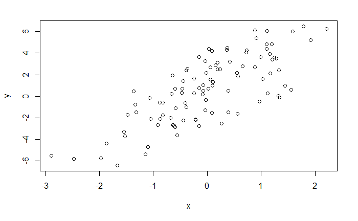

```r
plot(x, y)
```

Suppose instead we want to simulate from the following Poisson model:
$$Y \sim {\sf Poisson(\mu)}$$
$$\log(\mu) = \beta_{0} + \beta_{1}x$$
where $\beta_{0} = 0.5$ and $\beta_{1} = 0.3$. We will need to use `rpois`:

```r
set.seed(1) # set seed for reproducability
x <- rnorm(100) # set predictor x as Normal distribution
log.mu <- 0.5 + 0.3 * x # set log(mu) as outlined in model

y <- rpois(100, exp(log.mu)) # create model with above values and poisson distribution
summary(y)
```

```
   Min. 1st Qu.  Median    Mean 3rd Qu.    Max.
   0.00    1.00    1.00    1.55    2.00    6.00
```

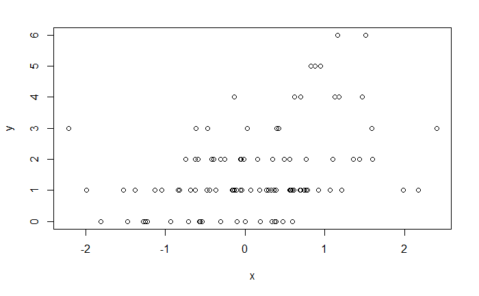

```r
plot(x, y)
```

#### Random sampling in R

`sample` allows you to draw randomly from a specific set of objects, allowing you to sample from arbitrary distributions.

For example:

```r
set.seed(1)
sample(1:10, 4)
```

```
[1] 3 4 5 7
```

```r
sample(1:10, 4)
```

```
[1] 3 9 8 5
```

```r
set.seed(1)
sample(1:10, 4)
```

```
[1] 3 4 5 7
```

```r
sample(letters, 5)
```

```
[1] "f" "w" "y" "p" "n"
```

```r
sample(1:10)
```

```
 [1]  1  2  9  5  3  4  8  6  7 10
```

```r
sample(1:10, replace = TRUE) # with replacement
```

```
 [1]  8 10  3  7  2  3  4  1  4  9
```

### Profiling in R

Profiling exists to answer the question: “Why is my code so slow?”.

It is a systematic way to examine how much time R is spending in different parts of a program, allowing us to optimise our code. Often code may run fine once, but if we iterate it 1000 times it may slow everything down.

General principles:

- Design first, optimise *second*.
- Don’t prematurely optimise!
- Measure, collect data, don’t guess.

#### Using `system.time()`

Allows you to test certain functions/blocks to see if they are taking an excessive amount of time, but you need to know *where* to look!

- Takes an R expression as input, returns the amount of time taken to evaluate it.
- If there’s an error, will give the time until the error occurred.
- Will return the time *in seconds* in a class `proc_time` including:
  - **user time**: time charged to the CPU to run the expression
  - **elapsed time**: “wall clock” time that *you* experience
    - may be *larger* than user time if CPU spends a lot of time idling
    - may be *smaller* than user time if we have multiple cores

#### Using R Profiler

`Rprof()` starts the R profiler, as long as R is compiled with profiler support, `summaryRprof()` takes the output of the profiler and summarises it.

**NB**: Do *not* use `system.time()` and `Rprof()` together, they are not compatible.

- `Rprof()` keeps track of the function call stack at regular intervals and tabulate how much time is spent on each function.
- Default sampling interval is 0.02 seconds, if your code is quicker than this, it will not be useful (or needed).
- To normalise the `summaryRprof()` data we can use:
  - `by.total` which divides the time spent by the total run time
  - `by.self` which does the same *after* subtracting time already spent in functions above in the call stack, often more useful